[OHI British Columbia](http://www.ohibc.org/) | [OHI Science](http://ohi-science.org) | [Citation policy](https://github.com/OHI-Science/ohiprep/releases)

# OHIBC: CW trash layers prep

Compiled on Mon Sep 19 14:50:36 2016 by ohara

# 1 Summary

This data is incorporated into the OHI British Columbia Clean Waters (CW) goal.

# 2 Data Source

**Reference**: [van Sebille et al, 2015](http://iopscience.iop.org/article/10.1088/1748-9326/10/12/124006/meta)

**Downloaded**: September 8, 2016 from Figshare: https://figshare.com/articles/data_of_microplastic_abundance_and_mass_from_Figure_3_of_Van_Sebille_et_al_2015_ERL_paper/1613256

**Native Data Resolution**: 1.0° in WGS84 projection

**Values**: Count (number/km2) and mass density (g/km2), based upon three different ocean circulation models (Lebreton, Maximenko, van Sebille)

**Time Range**: N/A

**Format**: CSV

# 3 Methods

## 3.1 Read in data

from: van Sebille et al 2015. A global inventory of small floating plastic debris.

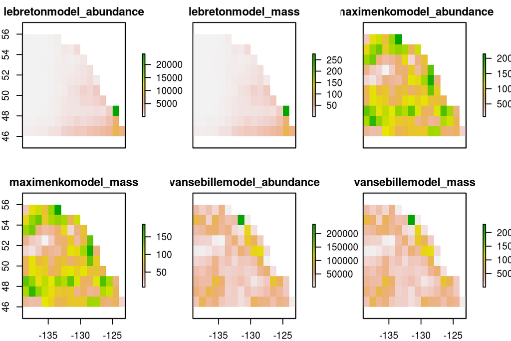

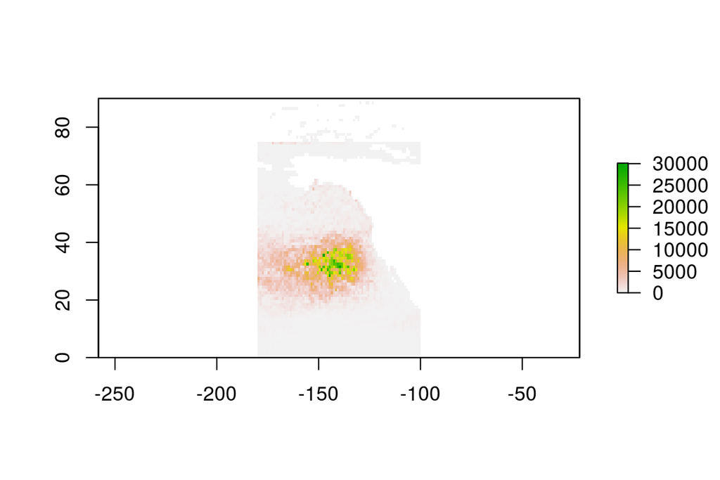

Crop to BC and interpolate using Thin Plate Spline to gapfill Strait of Georgia and coastal fjords.

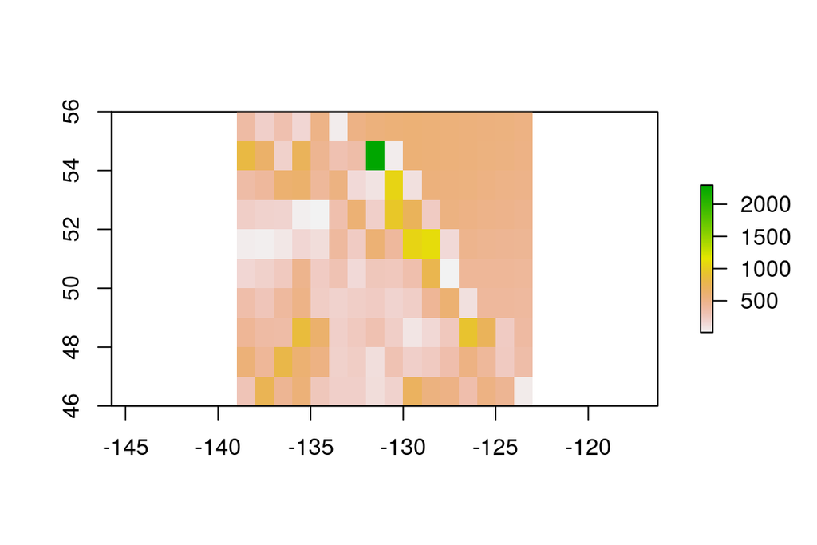

Reproject into BC Albers at 1000 m resolution

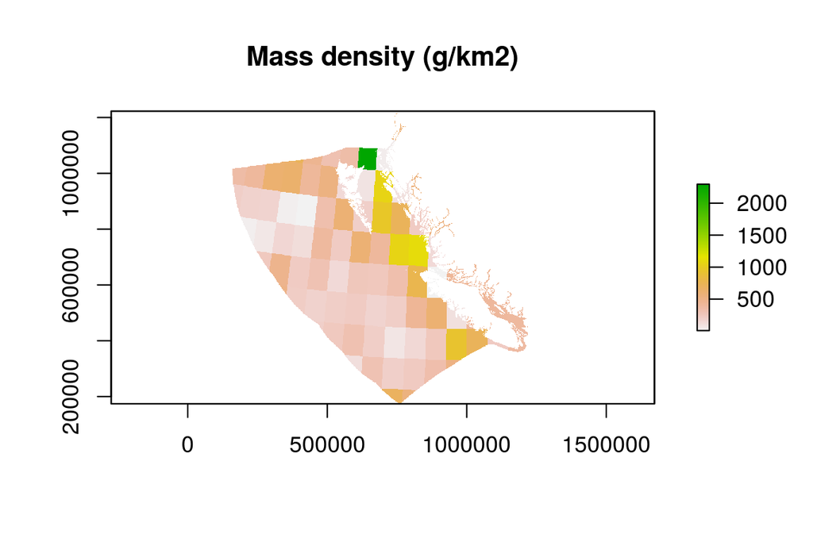

## 3.2 Log Transform

Transform the values to a log(x + 1) value.

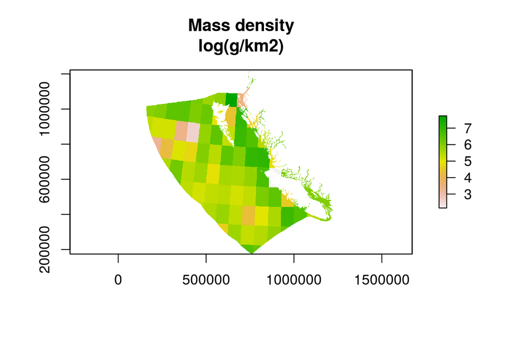

## 3.3 Rescale marine plastics pressure from zero to 1

Rescale all values to range from zero to 1, using several reference points for comparison. These rescalings will be done on both log-transformed and raw (linear) scales.

- 99.99% quantile across BC EEZ
  - Using this reference point for only the BC EEZ results in high pressures of trash; the distribution is relatively uniform across the EEZ, so the reference point is relatively low compared to the mean trash density. While this will still allow relative ranking, it may create a harsh penalty to the Clean Waters goal if the reference point is actually quite low.
- 110% of maximum value
  - Since the marine plastics raster from Van Sebille is relatively coarse (1 degree cells) it may be unnecessary to use a 99.99% (or other) quantile to filter out outliers, as they would presumably be averaged across a large area. While we could simply use the max value, we apply a 110% increase on the assumption that BC trash is relatively low and so could potentially get worse over time.
- 99.99% and 100% quantile of entire North Pacific basin
  - To further examine whether the reference point based on the BC EEZ is extremely low, we examine the score based on a higher reference point - using the values estimated for the entire North Pacific ocean basin. This should capture a larger range of debris values, providing a better idea of what is the “worst” case. While the cells are large and should spatially average extreme values, some filtering of outliers may prove useful, so we will examine both the 99.99%ile and 100%ile.

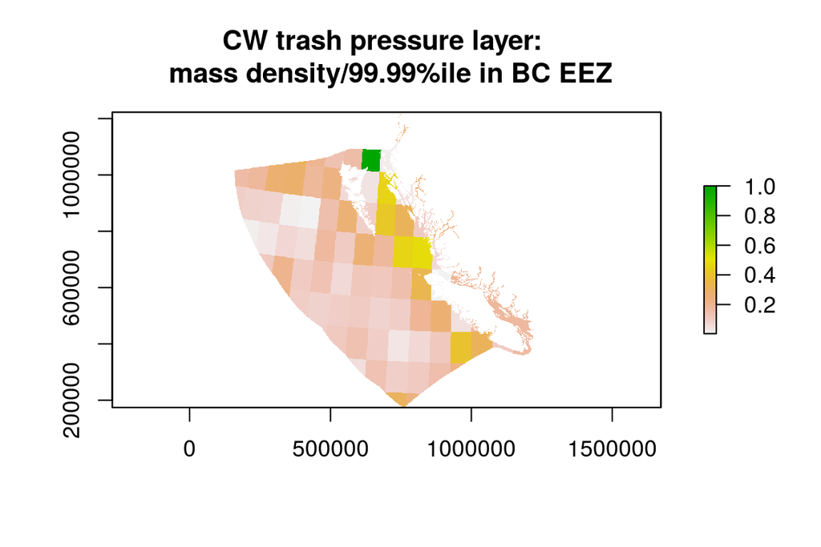

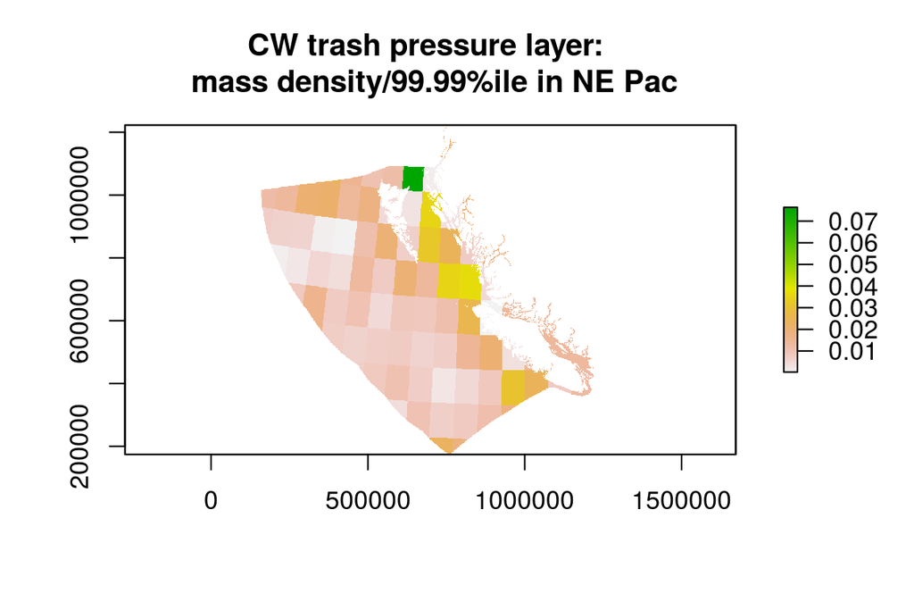

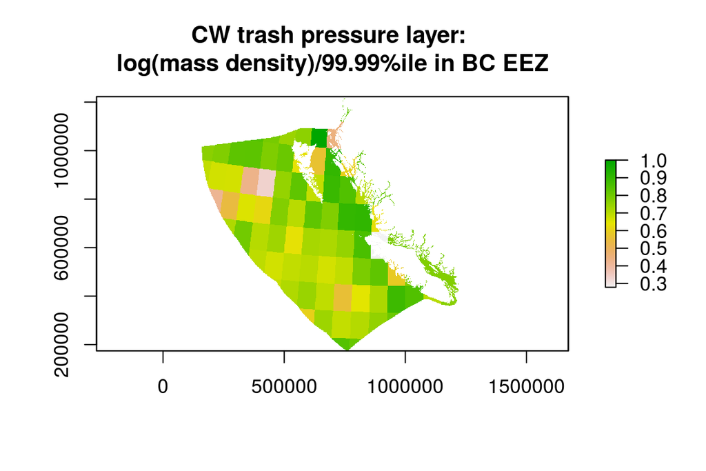

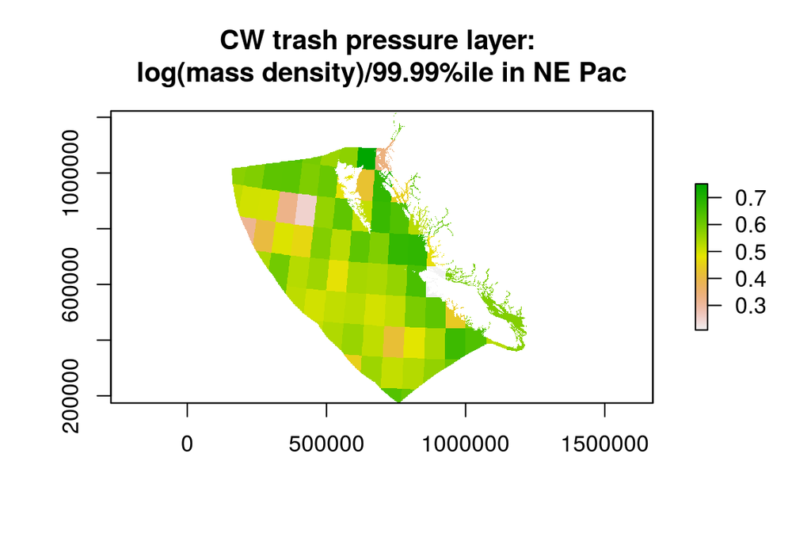

# 4 Provenance

- *Run ID: 1 (a1c7a8e); run tag: “standard run”*
- *Run elapsed time: 58.017 seconds; run memory usage: NA MB*
- *System info:*
  - *System: Linux, Release: 4.4.0-16-generic. Machine: x86_64. User: ohara.*
  - *R version: R version 3.3.1 (2016-06-21), Platform: x86_64-pc-linux-gnu, Running under: Ubuntu 14.04.5 LTS.*
  - *Attached base packages: stats, graphics, grDevices, utils, datasets, methods, base*
  - *Other attached packages: maptools_0.8-39, RColorBrewer_1.1-2, tmap_1.4-1, provRmd_0.1.1, ggplot2_2.1.0, readr_1.0.0, stringr_1.1.0, tidyr_0.6.0, dplyr_0.5.0, raster_2.5-8, rgdal_1.1-10, sp_1.2-3*

[figure not shown]

| sequence | file_name | parent_chunk | file_dir | filetype | uncomm_chgs | commit_hash_short |
| --- | --- | --- | --- | --- | --- | --- |
| 0 | cw_trash_prep.rmd | prov_footer | ~/github/ohibc/prep/cw/v2016 | parent_script | True | 1e33d98 |
| 0 | cw_trash_prep.rmd#interpolate_bc_sla | interpolate_bc_sla | ~/github/ohibc/prep/cw/v2016 | parent_chunk | True | 1e33d98 |
| 0 | cw_trash_prep.rmd#linear_rescales | linear_rescales | ~/github/ohibc/prep/cw/v2016 | parent_chunk | True | 1e33d98 |
| 0 | cw_trash_prep.rmd#log_rescales | log_rescales | ~/github/ohibc/prep/cw/v2016 | parent_chunk | True | 1e33d98 |
| 0 | cw_trash_prep.rmd#log_transform | log_transform | ~/github/ohibc/prep/cw/v2016 | parent_chunk | True | 1e33d98 |
| 0 | cw_trash_prep.rmd#prov_footer | prov_footer | ~/github/ohibc/prep/cw/v2016 | parent_chunk | True | 1e33d98 |
| 0 | cw_trash_prep.rmd#read_vanSebille_data | read_vanSebille_data | ~/github/ohibc/prep/cw/v2016 | parent_chunk | True | 1e33d98 |
| 0 | cw_trash_prep.rmd#reproject | reproject | ~/github/ohibc/prep/cw/v2016 | parent_chunk | True | 1e33d98 |
| 0 | cw_trash_prep.rmd#setup | setup | ~/github/ohibc/prep/cw/v2016 | parent_chunk | True | 1e33d98 |
| 1 | map_scores.R | setup | ~/github/ohibc/src/R | sourced_script | False | 9eddda8 |

[output cut: 28 more lines]